# 2025. Term 1. Big Data & Analysis.

## Final Report

- Student Name - Arslan Ibragimov
- Student Nickname - ARA
- Student ID - 22231809
- Student seat - 049

# Sentō Revival Project in Aichi – Understanding What Factors Drive Success in Public Bathhouses

## Project Background & Purpose

Sentō-themed restaurants in Aichi face growing challenges due to aging infrastructure, changing lifestyles, and limited budgets. While a few stylish locations in Tokyo have succeeded through design and social media, most rely on traditional features and loyal customers.

This project explores what truly drives success for these venues — not through costly renovations, but by analyzing factors like location, pricing, operating hours, and customer feedback. The goal is to identify realistic strategies to help them thrive in aging communities with limited resources.

## Step 1: Import Libraries & Load the Dataset

I begin the analysis by importing all necessary Python libraries for data manipulation, visualization, statistical modeling, and dimensionality reduction. These include:

- `pandas` and `numpy` for data handling,
- `matplotlib` and `seaborn` for visualization,
- `statsmodels` for regression analysis, and
- `sklearn` modules for scaling and Principal Component Analysis (PCA).

Then load the **Aichi Sento-Themed Restaurant Dataset** using `pandas.read_csv()` and preview the first five rows to understand the structure and format of the data.

This step sets the foundation for all further data exploration, cleaning, and analysis.

```python
# Required libraries
import pandas as pd
import numpy as np
import matplotlib.pyplot as plt
import seaborn as sns
import statsmodels.api as sm
from sklearn.preprocessing import StandardScaler
from sklearn.decomposition import PCA


# Configure visuals
sns.set(style='whitegrid')
plt.rcParams['figure.figsize'] = (12, 6)

# Load the dataset
df = pd.read_csv("Aichi_Dataset.csv")

print("📌 First 5 rows:")
display(df.head())
```

```
📌 First 5 rows:
```

|  | sento_id | monthly_visitors | average_price_for_use_yen | renovation_after_built | has_sauna | is_24_hour_open | open_hours_per_day | has_free_senior_day | has_kids_area_or_access | has_yoga_or_events | ... | district_density | target_elderly_pct | target_tourists_pct | avg_daily_temp | weekday_vs_weekend_ratio | has_loyalty_program | accepts_cash_only | accepts_usd | has_senior_discount | has_student_discount |
| --- | --- | --- | --- | --- | --- | --- | --- | --- | --- | --- | --- | --- | --- | --- | --- | --- | --- | --- | --- | --- | --- |
| 0 | 1 | 1790 | 1310 | 28 | 1 | 0 | 17 | 1 | 0 | 0 | ... | 12754 | 0.379103 | 0.277754 | 11.838651 | 0.584179 | 0 | 1 | 0 | 0 | 0 |
| 1 | 2 | 2340 | 470 | 14 | 1 | 0 | 20 | 0 | 0 | 0 | ... | 8415 | 0.425542 | 0.268759 | 20.518339 | 0.522975 | 0 | 0 | 0 | 0 | 0 |
| 2 | 3 | 2620 | 450 | 12 | 1 | 0 | 17 | 1 | 1 | 0 | ... | 6813 | 0.515462 | 0.125237 | 20.269261 | 0.776242 | 1 | 1 | 0 | 0 | 1 |
| 3 | 4 | 1870 | 680 | 25 | 0 | 0 | 9 | 0 | 0 | 0 | ... | 8234 | 0.258709 | 0.154585 | 14.311296 | 0.504794 | 0 | 0 | 0 | 0 | 0 |
| 4 | 5 | 1890 | 1210 | 10 | 1 | 0 | 17 | 0 | 0 | 0 | ... | 10766 | 0.490556 | 0.050362 | 14.470716 | 0.571684 | 0 | 0 | 0 | 1 | 1 |

5 rows × 33 columns

## Step 2: Dataset Structure & Schema Overview

To understand the composition of the dataset, I examine the overall structure using `df.shape` and `df.info()`. This helps:

- Confirm the dataset contains **2,000 records** and **33 variables**.
- Check the **data types** of each column (e.g., `int64`, `float64`).
- Verify that there are **no missing values** across all variables.
- Identify variable types:
  - **Categorical/Binary** (e.g., `has_sauna`, `is_near_subway`)
  - **Continuous/Numeric** (e.g., `average_price_for_use_yen`, `google_rating`)

This inspection ensures the dataset is complete and ready for cleaning, scaling, and further statistical analysis.

```python
# Show shape and column info
print("\n📌 Dataset Shape:", df.shape)
print("\n📌 Column Info:")
df.info()
```

```
📌 Dataset Shape: (2000, 33)

📌 Column Info:
<class 'pandas.core.frame.DataFrame'>
RangeIndex: 2000 entries, 0 to 1999
Data columns (total 33 columns):
 #   Column                     Non-Null Count  Dtype
---  ------                     --------------  -----
 0   sento_id                   2000 non-null   int64
 1   monthly_visitors           2000 non-null   int64
 2   average_price_for_use_yen  2000 non-null   int64
 3   renovation_after_built     2000 non-null   int64
 4   has_sauna                  2000 non-null   int64
 5   is_24_hour_open            2000 non-null   int64
 6   open_hours_per_day         2000 non-null   int64
```

[output cut: 28 more lines]

```python
print("\n📌 Descriptive Statistics:")
display(df.describe(include='all'))
```

```
📌 Descriptive Statistics:
```

|  | sento_id | monthly_visitors | average_price_for_use_yen | renovation_after_built | has_sauna | is_24_hour_open | open_hours_per_day | has_free_senior_day | has_kids_area_or_access | has_yoga_or_events | ... | district_density | target_elderly_pct | target_tourists_pct | avg_daily_temp | weekday_vs_weekend_ratio | has_loyalty_program | accepts_cash_only | accepts_usd | has_senior_discount | has_student_discount |
| --- | --- | --- | --- | --- | --- | --- | --- | --- | --- | --- | --- | --- | --- | --- | --- | --- | --- | --- | --- | --- | --- |
| count | 2000.000000 | 2000.000000 | 2000.000000 | 2000.000000 | 2000.000000 | 2000.000000 | 2000.000000 | 2000.000000 | 2000.000000 | 2000.00000 | ... | 2000.000000 | 2000.000000 | 2000.000000 | 2000.000000 | 2000.000000 | 2000.00000 | 2000.000000 | 2000.000000 | 2000.000000 | 2000.000000 |
| mean | 1000.500000 | 1883.380000 | 880.230000 | 27.326500 | 0.586000 | 0.092000 | 15.582500 | 0.398500 | 0.305000 | 0.19850 | ... | 8020.426500 | 0.448966 | 0.154431 | 15.984419 | 0.650901 | 0.30450 | 0.704500 | 0.057500 | 0.399000 | 0.295000 |
| std | 577.494589 | 474.562409 | 349.158564 | 12.948773 | 0.492672 | 0.289098 | 4.685101 | 0.489712 | 0.460523 | 0.39897 | ... | 2043.134326 | 0.150493 | 0.096146 | 5.965192 | 0.098297 | 0.46031 | 0.456381 | 0.232854 | 0.489815 | 0.456157 |
| min | 1.000000 | 180.000000 | 450.000000 | 5.000000 | 0.000000 | 0.000000 | 8.000000 | 0.000000 | 0.000000 | 0.00000 | ... | 1576.000000 | 0.000000 | 0.000000 | -1.461881 | 0.307681 | 0.00000 | 0.000000 | 0.000000 | 0.000000 | 0.000000 |
| 25% | 500.750000 | 1570.000000 | 570.000000 | 16.000000 | 0.000000 | 0.000000 | 11.000000 | 0.000000 | 0.000000 | 0.00000 | ... | 6694.000000 | 0.346439 | 0.082691 | 12.127146 | 0.584465 | 0.00000 | 0.000000 | 0.000000 | 0.000000 | 0.000000 |
| 50% | 1000.500000 | 1910.000000 | 840.000000 | 27.000000 | 1.000000 | 0.000000 | 16.000000 | 0.000000 | 0.000000 | 0.00000 | ... | 7976.000000 | 0.447719 | 0.152249 | 16.156894 | 0.650557 | 0.00000 | 1.000000 | 0.000000 | 0.000000 | 0.000000 |
| 75% | 1500.250000 | 2230.000000 | 1120.000000 | 39.000000 | 1.000000 | 0.000000 | 20.000000 | 1.000000 | 1.000000 | 0.00000 | ... | 9360.750000 | 0.551214 | 0.219849 | 19.998432 | 0.716683 | 1.00000 | 1.000000 | 0.000000 | 1.000000 | 1.000000 |
| max | 2000.000000 | 3000.000000 | 2300.000000 | 49.000000 | 1.000000 | 1.000000 | 23.000000 | 1.000000 | 1.000000 | 1.00000 | ... | 15148.000000 | 0.976829 | 0.500000 | 36.207898 | 0.966559 | 1.00000 | 1.000000 | 1.000000 | 1.000000 | 1.000000 |

8 rows × 33 columns

## Step 3: Identify Binary and Discrete Variables

In this step, identify and review all binary or low-cardinality categorical variables in the dataset. These are columns with only two or three unique values, such as `0` and `1`, indicating the presence or absence of a specific feature (e.g., amenities, discounts, or location traits).

Listing the unique values of these columns:

- Confirm correct data encoding (e.g., no unexpected values like 2 or NaN)
- Prepare these features for modeling and dimensionality reduction
- Easily identify suitable variables for interpretation or grouping (e.g., through PCA)

This review confirms that these variables are clean and correctly formatted for analysis.

```python
# Unique values for binary and categorical-type columns
binary_like = [col for col in df.columns if df[col].nunique() <= 3]
print("\n📌 Unique Values for Binary/Discrete Columns:")
for col in binary_like:
    print(f"{col}: {df[col].unique()}")
```

```
📌 Unique Values for Binary/Discrete Columns:
has_sauna: [1 0]
is_24_hour_open: [0 1]
has_free_senior_day: [1 0]
has_kids_area_or_access: [0 1]
has_yoga_or_events: [0 1]
murals_or_art_theme: [1 0]
has_cafe_or_rest_space: [1 0]
has_free_parking: [1 0]
has_bike_rack: [1 0]
is_near_subway: [1 0]
is_near_parks_or_green: [1 0]
is_near_nightlife: [1 0]
has_loyalty_program: [0 1]
accepts_cash_only: [1 0]
accepts_usd: [0 1]
has_senior_discount: [0 1]
has_student_discount: [0 1]
```

## Step 4: Visualizing Distributions of Numerical Variables

To better understand the underlying structure of the dataset, I visualize the distribution of each numerical variable using histograms. This helps:

- Identify the **range**, **central tendency**, and **skewness** of features such as `monthly_visitors`, `average_price_for_use_yen`, and `google_rating`.
- Detect potential **outliers** or **unusual distributions** in key variables.
- Understand the **binary distribution** of 0/1 features, confirming they are clean and usable.

This visual inspection is crucial before proceeding with statistical modeling, as it informs decisions like scaling, transformation, or variable selection for regression and PCA.

## Noteworthy & Unusual Distributions

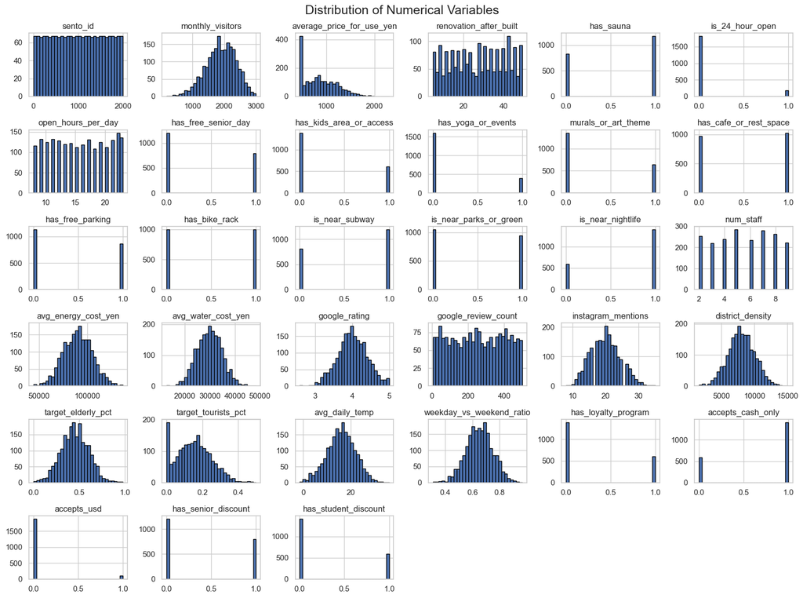

```python
# Histograms of numeric columns
df.hist(bins=30, figsize=(16, 12), edgecolor='black')
plt.suptitle("Distribution of Numerical Variables", fontsize=18)
plt.tight_layout()
plt.show()
```

## Step 5: Correlation Analysis

To explore the linear relationships between variables, I generate a correlation matrix using Pearson's correlation coefficient. The heatmap provides a quick visual overview of:

- **Positive and negative correlations** between variables
- Potential issues of **multicollinearity** (e.g., variables that are highly correlated with each other)
- Features that are potentially strong predictors of the target variable, `monthly_visitors`

This step helps guide the selection of variables for **multiple regression** and **PCA**, ensuring that we avoid redundancy and focus on meaningful relationships.

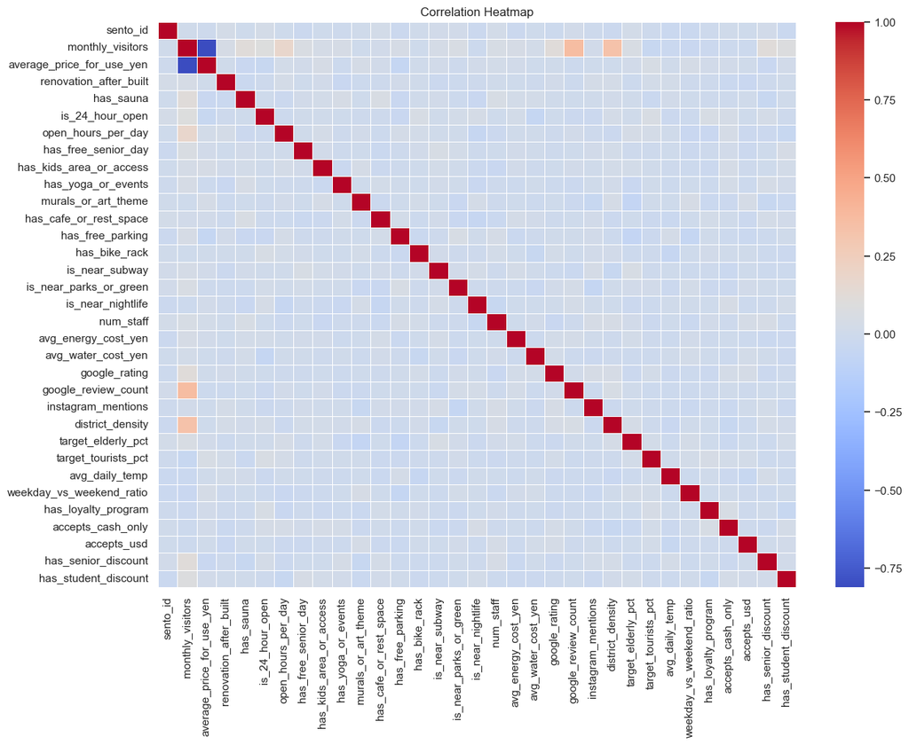

```python
# Correlation matrix
plt.figure(figsize=(14, 10))
sns.heatmap(df.corr(numeric_only=True), cmap='coolwarm', linewidths=0.5)
plt.title("Correlation Heatmap")
plt.show()
```

## Interpretation of the Correlation Heatmap

Visually, most correlations are very low or near zero, indicated by the dominant **light blue** color. This means that most variables are **not strongly linearly related to each other** — which is generally good for regression and PCA because it reduces the risk of multicollinearity.

## Stronger Correlations to Watch

1. `monthly_visitors` vs `google_review_count` → Positive Correlation (~ +0.4)

More reviews = more visitors. Makes sense — businesses with higher foot traffic tend to accumulate more reviews. Good candidate for regression or PCA inclusion.

Slightly visible on the map. Could suggest that better-rated places tend to have more reviews, but not strongly.

## Step 6: Correlation with Target Variable

When it's visually difficult to detect meaningful relationships in a full heatmap, it's often more effective to isolate and sort the correlations relative to the **target variable** — in this case, `monthly_visitors`.

By extracting and sorting the correlation values for `monthly_visitors`, we can:

- Clearly see which variables are **positively or negatively associated** with visitor numbers.
- Identify **strong predictors** (e.g., pricing, review count) to include in regression or PCA.
- Remove irrelevant or weakly correlated features to reduce noise in the model.

This step refines our focus for modeling and ensures we build data-driven insights based on actual statistical relationships.

## Selecting Predictors Based on Correlation

Based on the correlation values with `monthly_visitors`, I will manually select variables that show a meaningful relationship with the target.

- The strongest **positive correlation** is with `google_review_count` (0.36) and `district_density` (0.33), indicating that restaurants with more reviews and higher surrounding population density tend to attract more visitors.
- `average_price_for_use_yen` shows a strong **negative correlation** (-0.81), meaning that higher prices are strongly associated with lower visitor numbers.
- Other moderately correlated variables include `open_hours_per_day` (0.17).

🔎 I will use these variables as inputs for my initial **multiple regression model** and possibly also for **PCA-based clustering**.

```python
target_corr = corr_matrix['monthly_visitors'].sort_values(ascending=False)

print("📌 Correlation with Target (monthly_visitors):")
print(target_corr)
```

```
📌 Correlation with Target (monthly_visitors):
monthly_visitors             1.000000
google_review_count          0.366481
district_density             0.330761
open_hours_per_day           0.173769
google_rating                0.115347
has_senior_discount          0.115208
has_sauna                    0.109096
is_24_hour_open              0.087285
has_student_discount         0.082397
has_free_senior_day          0.059165
is_near_parks_or_green       0.058507
target_elderly_pct           0.056285
num_staff                    0.049230
avg_energy_cost_yen          0.044348
has_yoga_or_events           0.044171
has_free_parking             0.041733
renovation_after_built       0.040417
is_near_subway               0.035353
has_kids_area_or_access      0.031012
avg_water_cost_yen           0.020007
instagram_mentions           0.013779
has_cafe_or_rest_space       0.012971
sento_id                     0.004702
has_bike_rack                0.002262
murals_or_art_theme         -0.002709
accepts_usd                 -0.013394
accepts_cash_only           -0.015158
is_near_nightlife           -0.016394
has_loyalty_program         -0.023607
avg_daily_temp              -0.028831
weekday_vs_weekend_ratio    -0.038503
target_tourists_pct         -0.043874
average_price_for_use_yen   -0.811400
Name: monthly_visitors, dtype: float64
```

## Step 7: Multiple Linear Regression with Selected Features

Using the variables that showed the strongest correlation with `monthly_visitors`, we build a multiple linear regression model. The selected features include price, review count, population density, and opening hours.

After adding an intercept term, we fit the model using `statsmodels.OLS()` and review the summary output to evaluate the impact and significance of each predictor.

```python
# Remove leading/trailing spaces in column names
df.columns = df.columns.str.strip()


# Select your variables for Multiple Linear Regreession
selected_features = [
    'average_price_for_use_yen',
    'google_review_count',
    'district_density',
    'open_hours_per_day'
]

# Define independent (X) and dependent (y) variables
X = df[selected_features]
y = df['monthly_visitors']

# Add a constant
X = sm.add_constant(X)

# Fit the model
model = sm.OLS(y, X).fit()

print(model.summary())
```

```
                            OLS Regression Results
==============================================================================
Dep. Variable:       monthly_visitors   R-squared:                       0.919
Model:                            OLS   Adj. R-squared:                  0.919
Method:                 Least Squares   F-statistic:                     5684.
Date:                Fri, 09 May 2025   Prob (F-statistic):               0.00
Time:                        22:12:50   Log-Likelihood:                -12645.
No. Observations:                2000   AIC:                         2.530e+04
Df Residuals:                    1995   BIC:                         2.533e+04
Df Model:                           4
Covariance Type:            nonrobust
=============================================================================================
                                coef    std err          t      P>|t|      [0.025      0.975]
---------------------------------------------------------------------------------------------
const                      1675.7887     18.208     92.036      0.000    1640.080    1711.498
average_price_for_use_yen    -1.1013      0.009   -127.377      0.000      -1.118      -1.084
google_review_count           1.1064      0.021     52.686      0.000       1.065       1.148
district_density              0.0738      0.001     49.922      0.000       0.071       0.077
open_hours_per_day           19.6722      0.645     30.522      0.000      18.408      20.936
==============================================================================
Omnibus:                        2.419   Durbin-Watson:                   2.000
Prob(Omnibus):                  0.298   Jarque-Bera (JB):                2.369
Skew:                           0.049   Prob(JB):                        0.306
Kurtosis:                       2.863   Cond. No.                     5.02e+04
==============================================================================

Notes:
[1] Standard Errors assume that the covariance matrix of the errors is correctly specified.
[2] The condition number is large, 5.02e+04. This might indicate that there are
strong multicollinearity or other numerical problems.
```

## Step 8: Interpretation of Regression Results

The regression model explains the success of sentō-themed bathhouses through four key predictors, with a very strong **R-squared of 0.919**, meaning over 91% of the variation in monthly visitors is explained by this model.

### Key Findings:

- **Price is Critical**:  
  `average_price_for_use_yen` has a **strong negative coefficient** (-1.1013, *p* < 0.001). This means that as the average price increases by 1 yen, the number of visitors decreases by about 1 person per month. This confirms that **affordable pricing is essential for attracting more customers**, especially when the bathhouse isn't trendy.
- **Google Reviews Drive Visibility**:  
  `google_review_count` has a **strong positive effect** (+1.1064, *p* < 0.001). Every additional review is associated with approximately **one more monthly visitor**, showing that **online presence and customer engagement** significantly influence success.
- **Location Matters**:  
  `district_density` also has a **positive impact** (+0.0738, *p* < 0.001). Bathhouses located in more populated areas naturally draw more traffic, suggesting that **targeting higher-density districts** can lead to better performance.
- **Longer Hours Increase Foot Traffic**:  
  `open_hours_per_day` has a **positive coefficient** (+19.67, *p* < 0.001), meaning that for each additional hour of operation per day, the bathhouse gains nearly **20 more monthly visitors**. This shows the importance of **flexible, extended hours** in serving diverse customer schedules.

### Conclusion:

Even without trendy branding or expensive redesigns, sentō-style bathhouses can succeed by focusing on:

- **Lower pricing**
- **Strong online presence**
- **Strategic urban locations**
- **Longer operating hours**

These factors directly and measurably increase visitor numbers, making them critical levers for sustainable growth.

## Actual vs Predicted Visitors (Simple Regression)

This plot shows a strong alignment between the actual and predicted monthly visitors using the simple multiple regression model. The tight clustering around the red dashed line (perfect fit) indicates that the model performs very well, with high predictive accuracy across a wide range of values.

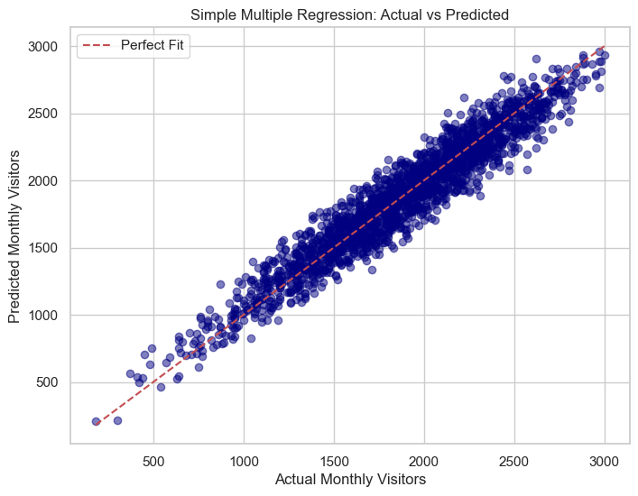

```python
y_pred_simple = model.predict(X)

# Plot
plt.figure(figsize=(8, 6))
plt.scatter(y, y_pred_simple, alpha=0.5, color='navy')
plt.plot([y.min(), y.max()], [y.min(), y.max()], 'r--', label='Perfect Fit')
plt.xlabel("Actual Monthly Visitors")
plt.ylabel("Predicted Monthly Visitors")
plt.title("Simple Multiple Regression: Actual vs Predicted")
plt.legend()
plt.grid(True)
plt.show()
```

## Step 9: Principal Component Regression (PCR)

To reduce dimensionality and address potential multicollinearity among correlated predictors, we apply **Principal Component Analysis (PCA)** to a selected group of independent variables. These include pricing, online reputation, location density, operating hours, and several binary features.

### Why PCA?

- PCA transforms the original correlated variables into a smaller set of **uncorrelated principal components**.
- This allows us to simplify the model while still capturing most of the original data’s variance.
- It’s especially useful when working with many features that may interact or overlap in meaning (e.g., discount types, amenities, and accessibility).

### How PCR Compares to Simple Multiple Regression:

| Aspect | Multiple Linear Regression | Principal Component Regression |
| --- | --- | --- |
| Variables | Uses **original features** | Uses **transformed components** |
| Interpretability | High – direct variable impact | Lower – abstract combinations |
| Risk of multicollinearity | Possible if variables are correlated | Avoided by construction |
| Dimensionality | Can increase with more features | Reduced by selecting fewer components |

### Trade-offs:

- PCR improves **model stability** and handles correlation well, but the components themselves are **less interpretable**.
- Unlike simple regression, you can’t say exactly *how much* each original variable influences the target — only how the grouped components do.

This step gives us a robust, cleaner model to validate the trends found in the earlier regression and better generalize our findings.

```python
# Example list of features
features = [
    "average_price_for_use_yen",
    "google_review_count",
    "district_density",
    "open_hours_per_day",
    "google_rating",
    "has_senior_discount",
    "has_sauna",
    "is_24_hour_open",
    "has_student_discount"
]

# Drop rows with missing values in selected columns
df_pca = df[features + ['monthly_visitors']].dropna()

scaler = StandardScaler()
X_scaled = scaler.fit_transform(df_pca[features])

y = df_pca['monthly_visitors']
```

```python
# Reduce to 3 components
pca = PCA(n_components=3)
X_pca = pca.fit_transform(X_scaled)

X_pca_df = pd.DataFrame(X_pca, columns=['PC1', 'PC2', 'PC3'])
```

```python
# Fit regression model
X_pca_df = sm.add_constant(X_pca_df)

pcr_model = sm.OLS(y, X_pca_df).fit()


print(pcr_model.summary())
```

```
                            OLS Regression Results
==============================================================================
Dep. Variable:       monthly_visitors   R-squared:                       0.433
Model:                            OLS   Adj. R-squared:                  0.433
Method:                 Least Squares   F-statistic:                     508.8
Date:                Fri, 09 May 2025   Prob (F-statistic):          1.51e-245
Time:                        22:35:28   Log-Likelihood:                -14594.
No. Observations:                2000   AIC:                         2.920e+04
Df Residuals:                    1996   BIC:                         2.922e+04
Df Model:                           3
Covariance Type:            nonrobust
==============================================================================
                 coef    std err          t      P>|t|      [0.025      0.975]
------------------------------------------------------------------------------
const       1883.3800      7.994    235.601      0.000    1867.703    1899.057
PC1          256.2451      7.590     33.763      0.000     241.361     271.129
PC2          120.3401      7.734     15.559      0.000     105.172     135.508
PC3          -93.9547      7.817    -12.019      0.000    -109.286     -78.624
==============================================================================
Omnibus:                       17.960   Durbin-Watson:                   2.027
Prob(Omnibus):                  0.000   Jarque-Bera (JB):               18.357
Skew:                          -0.232   Prob(JB):                     0.000103
Kurtosis:                       2.935   Cond. No.                         1.05
==============================================================================

Notes:
[1] Standard Errors assume that the covariance matrix of the errors is correctly specified.
```

## Step 10: Interpretation of Principal Component Regression (PCR) Results

The PCR model uses three principal components (PC1, PC2, PC3) derived from nine original features. It explains **43.3%** of the variance in monthly visitors (R² = 0.433), which is moderate and significantly lower than the simple regression model (R² = 0.919). However, the model is still statistically significant (*p* < 0.001) and avoids multicollinearity.

### Coefficient Insights:

All components are statistically significant (*p* < 0.001), showing they meaningfully contribute to predicting success, though **less precisely than individual variables in the earlier model**.

### Final Takeaway:

- While PCR helps simplify the model and avoid multicollinearity, it **sacrifices interpretability** — we can't directly say which exact features cause the changes in visitor numbers.
- The **original regression model remains more powerful for interpretation and decision-making**, but PCR supports and validates the broader trends.

## PCA Loadings: Variable Contribution to Each Component

This heatmap shows how much each original variable contributes to the three principal components. Higher absolute values indicate stronger influence, helping us interpret what each component represents in the regression model.

```python
#Show PCA Loadings

loadings = pd.DataFrame(pca.components_.T,
                        columns=['PC1', 'PC2', 'PC3'],
                        index=features)

print("📌 PCA Loadings:")
display(loadings)
```

```
📌 PCA Loadings:
```

|  | PC1 | PC2 | PC3 |
| --- | --- | --- | --- |
| average_price_for_use_yen | -0.467899 | 0.129972 | -0.047721 |
| google_review_count | 0.099100 | 0.488710 | -0.370191 |
| district_density | 0.393599 | 0.485151 | -0.232171 |
| open_hours_per_day | -0.427544 | 0.037825 | -0.409315 |
| google_rating | 0.077909 | 0.540572 | 0.031131 |
| has_senior_discount | 0.422373 | -0.325860 | -0.424161 |
| has_sauna | 0.140571 | 0.243076 | 0.610468 |
| is_24_hour_open | 0.436429 | -0.222700 | -0.077807 |
| has_student_discount | 0.197069 | -0.019578 | 0.282191 |

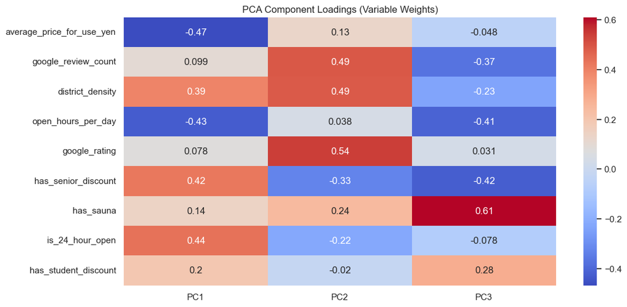

```python
sns.heatmap(loadings, annot=True, cmap='coolwarm')
plt.title("PCA Component Loadings (Variable Weights)")
plt.show()
```

## Step 11: Interpretation of PCA Loadings

To understand the meaning of each principal component (PC), we examine the **loadings**, which show how strongly each original variable contributes to each component.

### 🔹 PC1 — "Operational Value & Accessibility"

This component is most strongly influenced by:

- **Positively**: `is_24_hour_open` (0.44), `has_senior_discount` (0.42), `district_density` (0.39), `has_student_discount` (0.20)
- **Negatively**: `average_price_for_use_yen` (-0.47), `open_hours_per_day` (-0.43)

### 🔹 PC2 — "Digital Reputation & Experience Features"

Strongly loaded by:

- `google_rating` (0.54)
- `district_density` and `google_review_count` (both 0.49)
- `has_sauna` (0.24)

🔍 **Interpretation**: PC2 captures **online reputation and wellness features**. High values in this component reflect places that are digitally well-rated, reviewed, and offer relaxing amenities.

### 🔹 PC3 — "Amenity-Specific Factors"

- **Positively**: `has_sauna` (0.61), `has_student_discount` (0.28)
- **Negatively**: `has_senior_discount` (-0.42), `open_hours_per_day` (-0.41), `google_review_count` (-0.37)

🔍 **Interpretation**: PC3 reflects **amenity trade-offs** — such as promoting saunas or student perks, while associating less with senior support, longer hours, and review count. It may signal a different niche or visitor demographic.

### Why This Matters:

Understanding loadings helps **decode the PCA regression results**. For example:

- PC1 had the **strongest positive effect** on visitor numbers — so features like 24-hour access, discounts, and dense locations are powerful drivers.
- PC3 had a **negative effect**, suggesting that amenities like saunas or student discounts alone may not guarantee higher traffic without broader appeal or accessibility.

These insights refine our understanding of **what clusters of features drive sentō-style bathhouses success**, even in the absence of trendy branding.

## Actual vs Predicted Visitors (PCR Model)

This scatter plot compares the **actual** and **predicted** monthly visitor numbers from the Principal Component Regression model. The red dashed line represents perfect prediction. Points closer to the line indicate more accurate estimates, while deviations reflect model error.

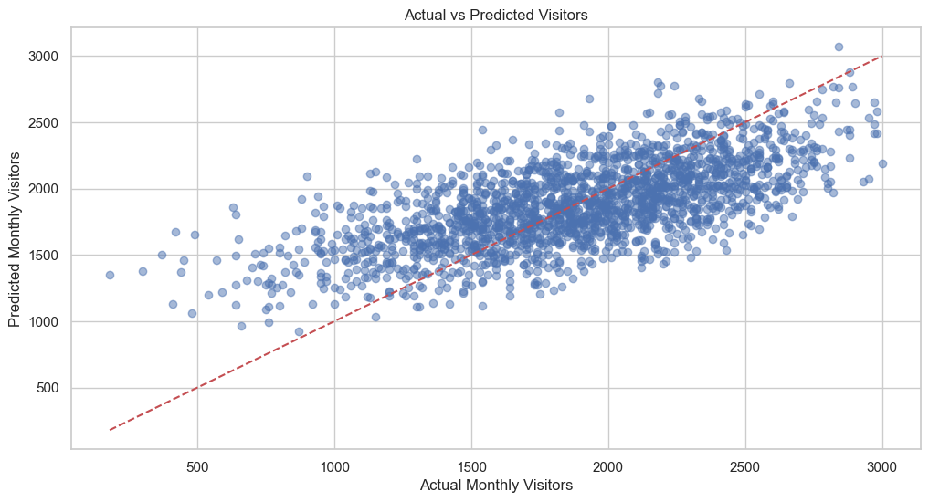

```python
y_pred = pcr_model.predict(X_pca_df)
plt.scatter(y, y_pred, alpha=0.5)
plt.plot([y.min(), y.max()], [y.min(), y.max()], 'r--')
plt.xlabel("Actual Monthly Visitors")
plt.ylabel("Predicted Monthly Visitors")
plt.title("Actual vs Predicted Visitors")
plt.grid(True)
plt.show()
```

## Final Recommendations for Sentō Bathhouses

### 🔍 Suggested Additional Data Sources

To further improve the analysis and model accuracy, the following data would be valuable:

- **Customer demographics**: Age, gender, and household type could help segment customer behavior.
- **Competitor data**: Locations, prices, and online ratings of nearby bathhouses or wellness centers for benchmarking.
- **Monthly revenue**: In addition to visitors, revenue figures would allow profitability analysis.
- **Marketing efforts**: Social media spend, promotions, or local partnerships could reveal drivers beyond location and amenities.
- **Customer satisfaction surveys**: Direct feedback on service quality, cleanliness, and atmosphere.

Collecting this information would allow for more personalized, data-driven strategies that support sustainable business growth even under tight budgets.